# Simple Linear Regression

Amruta

8/6/2019

### Step 1: Clear environment variables

```r
rm(list=ls(all=TRUE))
```

### Step 2: Set working Directory

```r
path <- getwd()
setwd(path)
```

### Step 3: Read the data from the csv file

```r
cars_data = read.csv(file="cars.csv", header=T)
names(cars_data)
```

```
## [1] "Id"        "Model"     "Price"     "Age_06_15"
```

```r
str(cars_data)
```

```
## 'data.frame':    1436 obs. of  4 variables:
##  $ Id       : int  1 2 3 4 5 6 7 8 9 10 ...
##  $ Model    : Factor w/ 372 levels " TOYOTA Corolla 1.3 16V HATCHB G6 2/3-Doors",..: 332 332 67 332 331 331 64 326 62 59 ...
##  $ Price    : int  13500 13750 13950 14950 13750 12950 16900 18600 21500 12950 ...
##  $ Age_06_15: int  57 57 58 60 64 66 61 64 61 57 ...
```

```r
summary(cars_data)
```

```
##        Id
##  Min.   :   1.0
##  1st Qu.: 361.8
##  Median : 721.5
##  Mean   : 721.6
##  3rd Qu.:1081.2
##  Max.   :1442.0
##
##                                                  Model
##  TOYOTA Corolla 1.6 16V HATCHB LINEA TERRA 2/3-Doors: 107
##  TOYOTA Corolla 1.3 16V HATCHB LINEA TERRA 2/3-Doors:  83
##  TOYOTA Corolla 1.6 16V LIFTB LINEA LUNA 4/5-Doors  :  79
##  TOYOTA Corolla 1.6 16V LIFTB LINEA TERRA 4/5-Doors :  70
##  TOYOTA Corolla 1.6 16V SEDAN LINEA TERRA 4/5-Doors :  43
##  TOYOTA Corolla 1.4 16V VVT I HATCHB TERRA 2/3-Doors:  42
##  (Other)                                            :1012
##      Price         Age_06_15
##  Min.   : 4350   Min.   : 35.00
##  1st Qu.: 8450   1st Qu.: 78.00
##  Median : 9900   Median : 95.00
##  Mean   :10731   Mean   : 89.95
##  3rd Qu.:11950   3rd Qu.:104.00
##  Max.   :32500   Max.   :114.00
##
```

### Step 4: Perform Exploratory Data Analysis and Data Pre-processing

Drop the Id, Model attributes:

```r
cars_data = cars_data[,-c(1,2)]
```

Summary of the data and look for any missing values:

```r
str(cars_data)
```

```
## 'data.frame':    1436 obs. of  2 variables:
##  $ Price    : int  13500 13750 13950 14950 13750 12950 16900 18600 21500 12950 ...
##  $ Age_06_15: int  57 57 58 60 64 66 61 64 61 57 ...
```

```r
summary(cars_data)
```

```
##      Price         Age_06_15
##  Min.   : 4350   Min.   : 35.00
##  1st Qu.: 8450   1st Qu.: 78.00
##  Median : 9900   Median : 95.00
##  Mean   :10731   Mean   : 89.95
##  3rd Qu.:11950   3rd Qu.:104.00
##  Max.   :32500   Max.   :114.00
```

No missing values

Correlation and Covariance between the attributes:

```r
cov(cars_data)
```

```
##                 Price   Age_06_15
## Price     13154872.10 -59136.1089
## Age_06_15   -59136.11    345.9596
```

The covariance of the Age of car and Price is -59136.11. It indicates a negative linear relationship between the two variables. This relation could be observed from the scatter plot also.

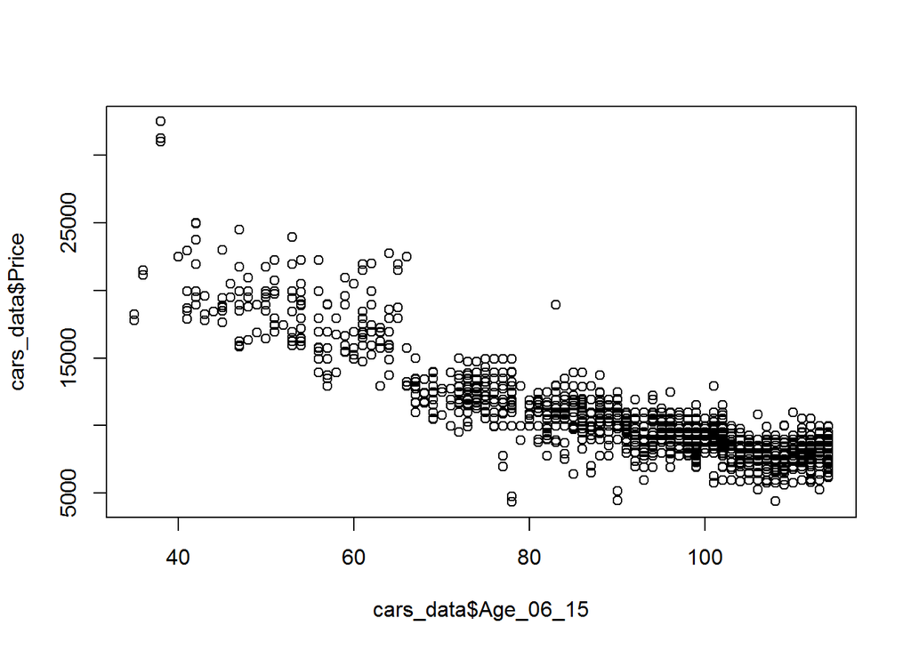

```r
plot(cars_data$Age_06_15, cars_data$Price)
```

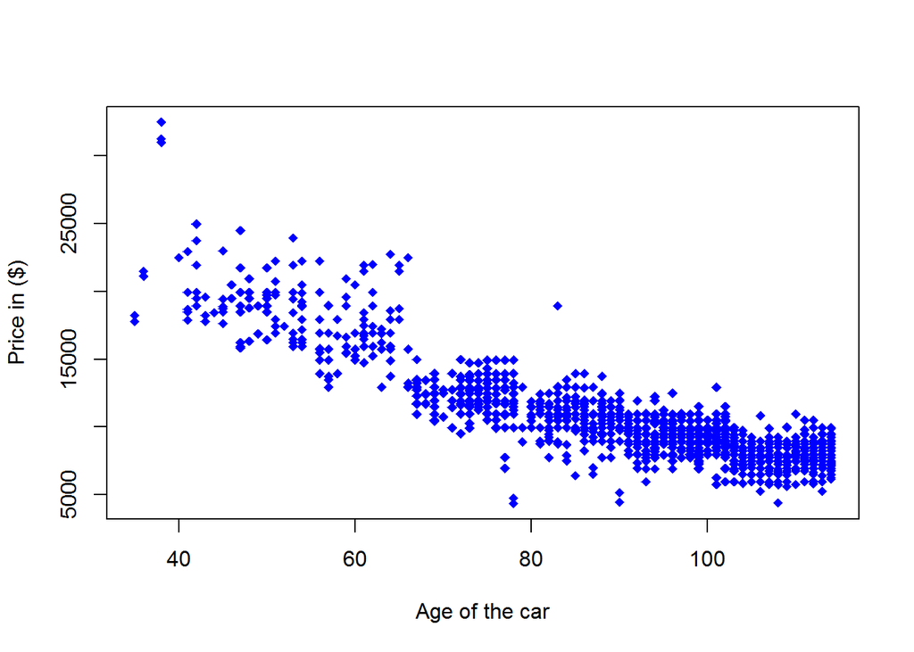

```r
plot(cars_data$Age_06_15, cars_data$Price, xlab = "Age of the car", ylab = "Price in ($)", pch=18,col = "blue")
```

```r
cor(cars_data)
```

```
##                Price  Age_06_15
## Price      1.0000000 -0.8765905
## Age_06_15 -0.8765905  1.0000000
```

```r
cor(cars_data$Age_06_15, cars_data$Price)
```

```
## [1] -0.8765905
```

#The correlation coefficient of the Age of car and Price is -0.8765905. #Since the value is close to 1 and has a -ve sign, we can conclude that the variables are strongly negatively correlated.

#### Step 5: Split the data into train and test datasets

Split in (train:test) in (70:30) ratio

```r
rows = seq(1, nrow(cars_data),1)
set.seed(123)
trainRows = sample(rows,(70*nrow(cars_data))/100)
cars_train = cars_data[trainRows,]
cars_test = cars_data[-trainRows,]
```

### Step 6: Linear regression model building

```r
LinReg = lm(Price ~ Age_06_15, data = cars_train)
coefficients(LinReg)
```

```
## (Intercept)   Age_06_15
##   25985.348    -170.057
```

### Summary of model:

```r
summary(LinReg)
```

```
##
## Call:
## lm(formula = Price ~ Age_06_15, data = cars_train)
##
## Residuals:
##     Min      1Q  Median      3Q     Max
## -7970.9  -941.0    -9.3   860.5 11751.8
##
## Coefficients:
##              Estimate Std. Error t value Pr(>|t|)
## (Intercept) 25985.348    266.910   97.36   <2e-16 ***
## Age_06_15    -170.057      2.905  -58.53   <2e-16 ***
## ---
## Signif. codes:  0 '***' 0.001 '**' 0.01 '*' 0.05 '.' 0.1 ' ' 1
##
## Residual standard error: 1689 on 1003 degrees of freedom
## Multiple R-squared:  0.7735, Adjusted R-squared:  0.7733
## F-statistic:  3426 on 1 and 1003 DF,  p-value: < 2.2e-16
```

Optional for info: To extract the coefficients:

```r
coefficients(LinReg)
```

```
## (Intercept)   Age_06_15
##   25985.348    -170.057
```

```r
coefficients(LinReg)[1]
```

```
## (Intercept)
##    25985.35
```

```r
coefficients(LinReg)[2]
```

```
## Age_06_15
##  -170.057
```

```r
names(coefficients(LinReg))
```

```
## [1] "(Intercept)" "Age_06_15"
```

To extract the residuals:

```r
LinReg$residuals
```

[output not shown]

[output cut: 347 more lines]

[output not shown]

To extract the train predictions:

```r
LinReg$fitted.values
```

[output not shown]

[output cut: 233 more lines]

[output not shown]

### Step 7: Check for validity of linear regression assumptions

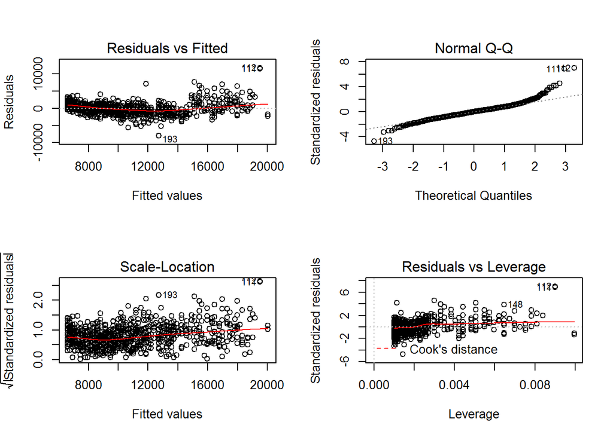

```r
par(mfrow = c(2,2))
plot(LinReg)
```

```r
par(mfrow = c(1,1))
```

### Step 8: Predict on testdata

```r
test_prediction = predict(LinReg, cars_test)
test_actual = cars_test$Price
```

### Step 9: Error Metrics

Error verification on train data

```r
library(DMwR)
regr.eval(cars_train$Price, LinReg$fitted.values)
```

```
##          mae          mse         rmse         mape
## 1.216922e+03 2.845463e+06 1.686850e+03 1.186451e-01
```

Error verification on test data

```r
regr.eval(test_actual, test_prediction)
```

```
##          mae          mse         rmse         mape
## 1.307160e+03 3.514942e+06 1.874818e+03 1.250985e-01
```

### Step 10: Confidence and Prediction Intervals

Confidence Intervals talk about the average values intervals Prediction Intervals talk about the all individual values intervals

```r
Conf_Pred = data.frame(predict(LinReg, cars_test, interval="confidence",level=0.95))
Pred_Pred = data.frame(predict(LinReg, cars_test, interval="prediction",level=0.95))

names(Conf_Pred)
```

```
## [1] "fit" "lwr" "upr"
```

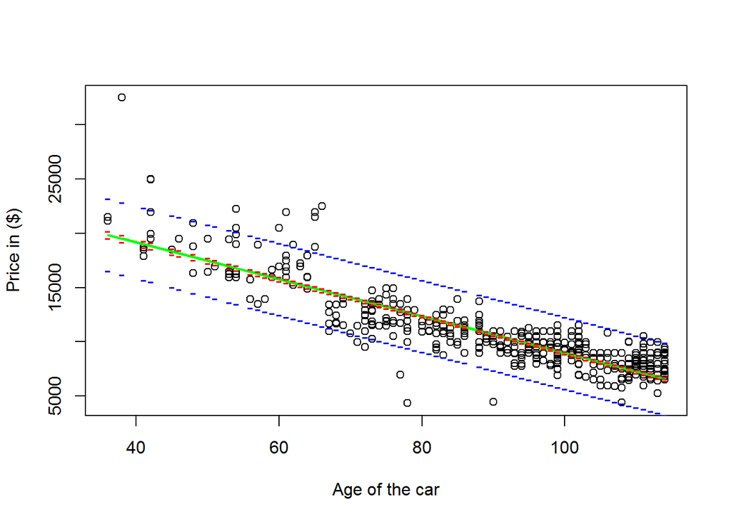

```r
plot(cars_test$Age_06_15, cars_test$Price, xlab = "Age of the car", ylab = "Price in ($)")

points(cars_test$Age_06_15,Conf_Pred$fit,type="l", col="green", lwd=2)
points(cars_test$Age_06_15,Conf_Pred$lwr,pch="-", col="red", lwd=4)
points(cars_test$Age_06_15,Conf_Pred$upr,pch="-", col="red", lwd=4)
points(cars_test$Age_06_15,Pred_Pred$lwr,pch="-", col="blue", lwd=4)
points(cars_test$Age_06_15,Pred_Pred$upr,pch="-", col="blue", lwd=4)
```

Confidence intervals tell you about how well you have determined the mean. Assume that the data really are randomly sampled from a Gaussian distribution. If you do this many times, and calculate a confidence interval of the mean from each sample, you’d expect about 95 % of those intervals to include the true value of the population mean. The key point is that the confidence interval tells you about the likely location of the true population parameter.

Prediction intervals tell you where you can expect to see the next data point sampled. Assume that the data really are randomly sampled from a Gaussian distribution. Collect a sample of data and calculate a prediction interval. Then sample one more value from the population. If you do this many times, you’d expect that next value to lie within that prediction interval in 95% of the samples.The key point is that the prediction interval tells you about the distribution of values, not the uncertainty in determining the population mean.